# R Notebook

```r
install.packages("clustAnalytics")
```

```
Error in install.packages : Updating loaded packages
```

```r
library("igraph")
library("igraphdata")
library("clustAnalytics") #contains various methods to assess the quality of clusterings
```

## Jaccard similarity

Given two different clusterings of the same network, it outputs a table of the Jaccard index between each of their clusters (i.e. a table that includes the Jaccard index between each cluster of labeling 1 and each cluster of labeling 2).

```r
jaccard_sim <- function(GT_clust, clust) {
  # Get unique cluster labels in both lists
  unique_GT <- unique(GT_clust)
  unique_clust <- unique(clust)

  # Initialize an empty matrix to store Jaccard similarities
  JS_matrix <- matrix(0, nrow = length(unique_GT), ncol = length(unique_clust))

  # Compute the Jaccard similarity for each pair of clusters
  for (i in 1:length(unique_GT)) {
    for (j in 1:length(unique_clust)) {
      # Get the nodes in the i-th GT cluster and j-th predicted cluster
      nodes_GT <- which(GT_clust == unique_GT[i])
      nodes_clust <- which(clust == unique_clust[j])

      # Calculate intersection and union of the two sets
      intersection_size <- length(intersect(nodes_GT, nodes_clust))
      union_size <- length(union(nodes_GT, nodes_clust))

      # Calculate Jaccard similarity and store it in the matrix
      JS_matrix[i, j] <- intersection_size / union_size
    }
  }

  # Set row and column names for the matrix
  rownames(JS_matrix) <- paste(unique_GT)
  colnames(JS_matrix) <- paste(unique_clust)

  return(JS_matrix)
}
```

## Match clusters

For each cluster of labeling 1, identifies which is the cluster of labeling 2 that is more similar according to the Jaccard index, and returns all these indices indicating which clusters they correspond to.

```r
match_clusters <- function(JS_matrix, name_GT="GT", name_alg="alg") {
  # Initialize an empty list to store the matching pairs
  MC_list <- list()

  # Loop over each cluster in the ground truth (GT) (rows of JS_matrix)
  for (i in 1:nrow(JS_matrix)) {
    # Find the index of the cluster in 'alg' with the highest Jaccard similarity for cluster i in 'GT'
    best_match_index <- which.max(JS_matrix[i, ])

    # Get the name of the clusters
    GT_cluster_name <- paste(name_GT, rownames(JS_matrix)[i], sep = ".")
    alg_cluster_name <- paste(name_alg, colnames(JS_matrix)[best_match_index], sep = ".")

    # Get the Jaccard similarity value
    similarity_value <- JS_matrix[i, best_match_index]

    # Create a named entry in the list with the cluster pair and similarity
    MC_list[[paste("(", GT_cluster_name, ",", alg_cluster_name, ")", sep = "")]] <- similarity_value
  }

  # Convert the list to a named vector (keys are the cluster pairs, values are the similarity values)
  MC_vector <- unlist(MC_list)

  # Convert the vector to a matrix format (one row with the Jaccard similarity values)
  MC_matrix <- matrix(MC_vector, nrow = 1)

  # Set the column names to be the cluster pairs
  colnames(MC_matrix) <- names(MC_vector)

  # Return the matrix
  return(MC_matrix)
}
```

## Weighted mean

Computes the weighted mean of the vector of values output by previous function (weights given by fraction of number of nodes in each cluster).

This quantity we will consider as the (global) Jaccard similarity of the two clusterings.

```r
Wmean <- function(MC_matrix, GT_clust, clust, algorithm_name) {
  # Initialize variables
  total_weighted_similarity <- 0
  total_weight <- 0

  # Extract cluster pair names from the column names of the MC_matrix
  cluster_pairs <- colnames(MC_matrix)

  # Loop over each cluster pair to calculate weighted similarity
  for (pair in cluster_pairs) {
    # Remove parentheses first
    clean_pair <- gsub("[()]", "", pair)

    # Split the pair into GT and algorithm cluster parts
    gt_cluster <- as.numeric(sub("GT\\.", "", strsplit(clean_pair, ",")[[1]][1]))  # Remove "GT." and convert to numeric
    lv_cluster <- as.numeric(sub(paste0(algorithm_name, "\\."), "", strsplit(clean_pair, ",")[[1]][2]))  # Remove dynamic algorithm prefix

    # Get the size of the clusters (number of nodes)
    gt_size <- sum(GT_clust == gt_cluster)
    lv_size <- sum(clust == lv_cluster)

    # Calculate the weight for the cluster pair (fraction of nodes in both clusters)
    weight <- gt_size / length(GT_clust) + lv_size / length(clust)

    # Get the Jaccard similarity value from the matrix
    similarity_value <- MC_matrix[1, pair]

    # Update the weighted sum
    total_weighted_similarity <- total_weighted_similarity + (weight * similarity_value)
    total_weight <- total_weight + weight
  }

  # Calculate the weighted mean
  w_mean_value <- total_weighted_similarity / total_weight

  return(w_mean_value)
}
```

## Alternative to global Jaccard similarity

```r
# TODO: Think about an alternative.
# Can you think of another way of combining the vector of Jaccard indices obtained in match_clusters() to quantify clusterings similarity?

# Harmonic Mean for Global Jaccard Similarity
harmonic_mean <- function(MC_matrix, GT_clust, clust, algorithm_name) {
  # Extract similarities from the match clusters matrix
  similarities <- as.numeric(MC_matrix)
  # Calculate harmonic mean
  harmonic_mean_value <- length(similarities) / sum(1 / similarities)
  return(harmonic_mean_value)
}
```

# Code to plot a graph and its clustering

```r
# Plot community structure for a given graph and clustering
plot_communities <- function(graph, clustering, title) {
  plot(graph, vertex.color = clustering, main = title, vertex.label = NA, vertex.size = 10)
}

# Plot dendrogram for hierarchical clustering
plot_dendrogram <- function(graph, algorithm) {
  if (algorithm == "fastgreedy") {
    dendrogram <- cluster_fast_greedy(graph)
    dendPlot(dendrogram)
  } else {
    message("Dendrogram not supported for this algorithm.")
  }
}
```

# Load/generate datasets

```r
# Karate
data(karate,package="igraphdata")
```

```
This graph was created by an old(er) igraph version.
  Call upgrade_graph() on it to use with the current igraph version
  For now we convert it on the fly...
```

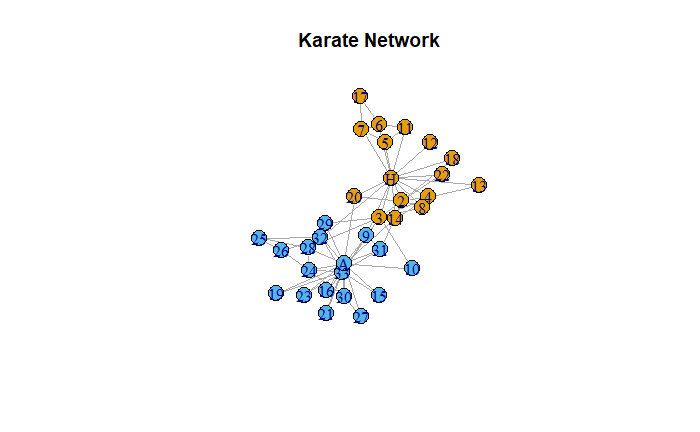

```r
plot(karate,main = "Karate Network")
```

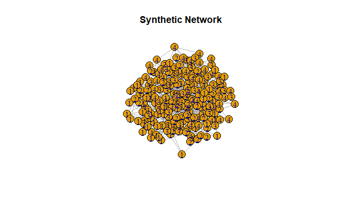

```r
# Synthetic network: scale-free degree distribution, 200 nodes, 800 edges and 4 communities
B <- matrix(c(1, 0.5, 0.3, 0.1,
              0.5, 1, 0.4, 0.8,
              0.3, 0.4, 1, 0.7,
              0.1, 0.8, 0.7, 1), ncol=4)
synthetic_graph <- barabasi_albert_blocks(m=4, p=c(0.25, 0.25, 0.25, 0.25), B=B, t_max=200,
                     type="Hajek", sample_with_replacement = FALSE)
plot(synthetic_graph,main = "Synthetic Network")
```

```r
# ENRON
data(enron,package="igraphdata")
```

```
This graph was created by an old(er) igraph version.
  Call upgrade_graph() on it to use with the current igraph version
  For now we convert it on the fly...
```

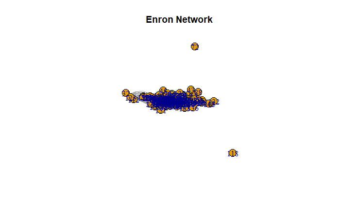

```r
enron_adj <- as_adjacency_matrix(as.undirected(enron,mode = "each"))
enron_graph <- graph_from_adjacency_matrix(enron_adj, mode = "undirected", diag = FALSE)
plot(enron_graph, main="Enron Network")
```

```r
#TODO: A network of your choice with no known co  mmunity structure. You can use networks from network repositories available in the web or from the igraphdata package.
# Random Erdos-Renyi graph
# custom_graph <- erdos.renyi.game(150, p = 0.05)
# plot(custom_graph, main = "Custom Network")
#
# # Example edge list file (replace with your file or URL)
# file_url <- "https://snap.stanford.edu/data/facebook_combined.txt.gz"
#
# # Download and read the file
# download.file(file_url, destfile = "facebook_combined.txt.gz")
# edge_list <- read.table("facebook_combined.txt.gz", header = FALSE)
#
#
# # Create the graph
# custom_graph <- graph_from_edgelist(as.matrix((edge_list+1)[(0:800),]), directed = FALSE)
#
#
# # Plot the graph
# plot(custom_graph, vertex.label = NA, main = "Facebook Social Network")

data("UKfaculty",package="igraphdata")
```

```
This graph was created by an old(er) igraph version.
  Call upgrade_graph() on it to use with the current igraph version
  For now we convert it on the fly...
```

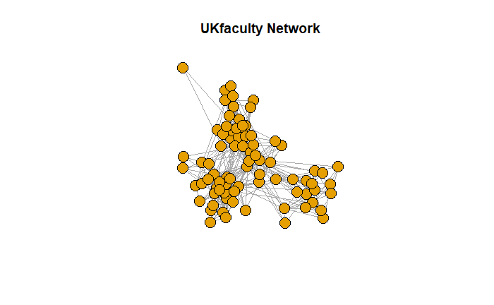

```r
undirected_graph <- as.undirected(UKfaculty, mode = "collapse")  # Combine directed edges into one undirected edge
plot(undirected_graph,main = "UKfaculty Network",vertex.label=NA)
```

```r
custom_graph<-undirected_graph
```

## Define functions

```r
get_cluster_memberships_from_graph <- function(graph, algorithm) {

  # Clustering using Walktrap
  if (algorithm == "walktrap") {
    results <- cluster_walktrap(graph)
  }

  # Clustering using Betweenness
  else if (algorithm == "betweenness") {
    results <- cluster_edge_betweenness(graph)
  }

  # Clustering using Fast Greedy
  else if (algorithm == "fastgreedy") {
    results <- cluster_fast_greedy(graph)
  }

  # Clustering using Label Propagation
  else if (algorithm == "propagation") {
    results <- cluster_label_prop(graph)
  }

  # Clustering using Eigenvector
  else if (algorithm == "eigenvector") {
    results <- cluster_eigenvector(graph)
  }

  # Clustering using Multilevel
  else if (algorithm == "multilevel") {
    results <- cluster_louvain(graph)
  }

  # Clustering using Optimal (Modularity-based)
  else if (algorithm == "optimal") {
    results <- cluster_optimal(graph)
  }

  # Clustering using Spinglass
  else if (algorithm == "spinglass") {
    results <- cluster_spinglass(graph)
  }

  # Clustering using Infomap
  else if (algorithm == "infomap") {
    results <- cluster_infomap(graph)
  }

  # Check if the algorithm provided is valid
  else {
    stop("Invalid algorithm specified. Please choose one of: 'walktrap', 'betweenness', 'fastgreedy', 'propagation', 'eigenvector', 'multilevel', 'optimal', 'spinglass', 'infomap'.")
  }
  cluster_list <- unname(membership(results))
  # Return the clustering result
  return(cluster_list)
}
```

## 1. Define the algorithms we want to use

```r
algorithm_functions <- list(
  walktrap = cluster_walktrap, #is asked
 betweenness = cluster_edge_betweenness, #is asked
  #fastgreedy = cluster_fast_greedy,
  propagation = cluster_label_prop, #is asked
  #eigenvector = cluster_eigenvector,
 multilevel = cluster_louvain, #is asked
  #optimal = cluster_optimal,
  #spinglass = cluster_spinglass,
  infomap = cluster_infomap
)
```

## 2. Define the scoring functions we want to use to evaluate the clustering significance (a representative of each class) + Jaccard similarity (local and global)

```r
#Internal connectivity (high is best)
int_cnctvty <- c(
  "clustering coef",
  "internal density",
  "edges inside",
  "av degree",
  "FOMD"
)
#External connectivity (low is best)
ext_cnctvty <- c(
  "expansion",
  "cut ratio"
)
#Combine internal and external connectivity (low is best)
int_ext_cnctvty <- c(
  "conductance",
  "norm cut",
  "max ODF",
  "average ODF",
  "flake ODF"
)
#Based on a network model (high is best)
net_model <- c(
  "modularity"
)
```

## 3. Find a good reference clustering for each network

- Ground truth for Karate and Synthetic graph
- Best ranked clustering (according to your selected group of scoring functions) for ENRON and the other.

[output not shown]

```r
#Find best algorithm to get the clustering GT of ENRON and custom

# Define metrics of interest
all_interested_metrics <- c(int_cnctvty, ext_cnctvty, int_ext_cnctvty, net_model)


# Evaluate significance and determine the best algorithm for ENRON
no_clustering_coef_flag <- !("clustering coef" %in% int_cnctvty)
enron_scores <- evaluate_significance(
  enron_graph,
  alg_list = algorithm_functions,
  no_clustering_coef = no_clustering_coef_flag
)
enron_scores_filtered <- enron_scores[rownames(enron_scores) %in% all_interested_metrics, ]
enron_best_algorithm <- find_best_algorithm(
  enron_scores_filtered, int_cnctvty, ext_cnctvty, int_ext_cnctvty, net_model
)
```

```
   walktrap betweenness propagation  multilevel     infomap
          0           2           1          10           0
```

```r
print(paste("Best algorithm for ENRON:", enron_best_algorithm))
```

```
[1] "Best algorithm for ENRON: multilevel"
```

```r
# Evaluate significance and determine the best algorithm for Custom Network
custom_scores <- evaluate_significance(
  custom_graph,
  alg_list = algorithm_functions,
  no_clustering_coef = no_clustering_coef_flag
)
custom_scores_filtered <- custom_scores[rownames(custom_scores) %in% all_interested_metrics, ]
custom_best_algorithm <- find_best_algorithm(
  custom_scores_filtered, int_cnctvty, ext_cnctvty, int_ext_cnctvty, net_model
)
```

```
   walktrap betweenness propagation  multilevel     infomap
          8           3           2           0           1
```

```r
print(paste("Best algorithm for Custom Network:", custom_best_algorithm))
```

```
[1] "Best algorithm for Custom Network: walktrap"
```

```r
# Extract GT clustering based on the best algorithm
enron_GT <- get_cluster_memberships_from_graph(enron_graph, enron_best_algorithm)
custom_GT <- get_cluster_memberships_from_graph(custom_graph, custom_best_algorithm)

# Print results
print("ENRON GT Clustering:")
```

```
[1] "ENRON GT Clustering:"
```

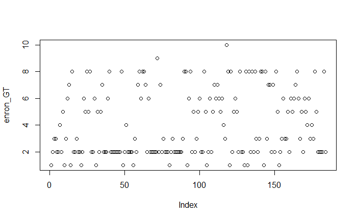

```r
plot(enron_GT)
```

```r
print("Custom Network GT Clustering:")
```

```
[1] "Custom Network GT Clustering:"
```

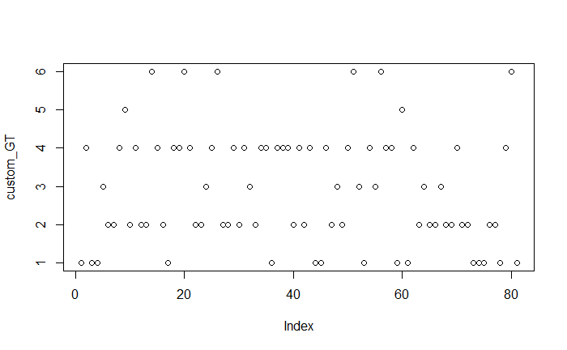

```r
plot(custom_GT)
```

```r
# #
# # no_clustering_coef_flag <- !("clustering coef" %in% int_cnctvty)
# all_scores <- evaluate_significance(
#   karate,
#   alg_list=algorithm_functions,
#   no_clustering_coef = no_clustering_coef_flag
#   )
#
# scores <- all_scores[rownames(all_scores) %in% all_interested_metrics, ]
# best_algorithm <- find_best_algorithm(scores, int_cnctvty, ext_cnctvty, int_ext_cnctvty, net_model)
# best_algorithm
```

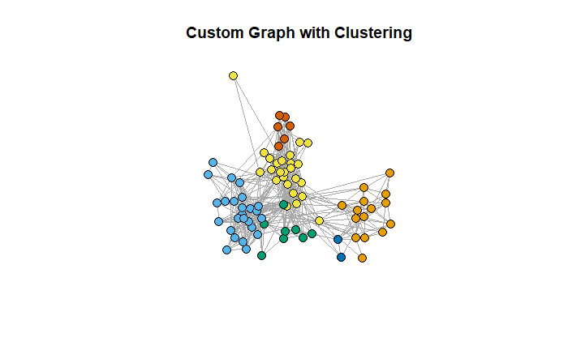

```r
plot_communities(
  custom_graph,
  custom_GT,  # Use your clustering results
  "Custom Graph with Clustering"
)
```

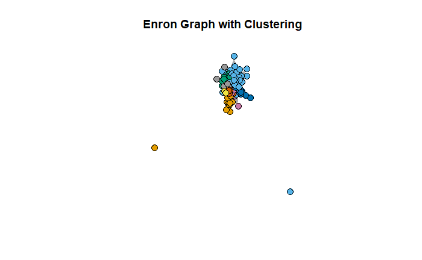

```r
plot_communities(
  enron_graph,
  enron_GT,  # Use your clustering results
  "Enron Graph with Clustering"
)
```

## 4. Evaluate

[figure not shown]

```r
enron_GT
```

```
  [1]  1  2  3  3  2  2  4  2  5  1  3  6  7  1  8  2  2  3  2  2  1  2  6  5  8  5  8  2  2  6  1  5  2  5  7  2  2  2  6  8  2  2  2  2  2  2  2  8  1  2
 [51]  4  2  2  2  2  1  3  2  7  8  6  8  8  7  2  6  2  2  2  2  2  9  2  7  2  3  2  2  2  1  2  3  2  2  2  2  2  2  3  8  8  1  6  8  2  5  2  3  5  6
[101]  2  2  8  5  1  2  6  2  5  7  6  7  6  5  6  4  3 10  8  1  8  2  5  6  5  2  8  2  2  1  8  1  8  2  8  2  8  3  2  3  8  8  1  8  3  7  7  2  7  2
[151]  8  5  1  2  3  6  3  3  5  2  6  5  6  7  8  6  3  5  2  6  5  4  6  3  4  3  8  5  2  2  2  2  8  2
```

```r
# Summarize results into a table
summarize_JS <- function(network_name, results) {
  summary <- data.frame(
    Algorithm = names(results),
    Weighted_JS = sapply(results, function(r) r$weighted_js),
    Harmonic_JS = sapply(results, function(r) r$harmonic_js)
  )
  print(paste("Results for", network_name))
  # print(summary)
  return(summary)
}

summarize_metrics <- function(network_name, results) {
  summary <- metrics = results$walktrap$metrics

  print(paste("Results for", network_name))
  # print(summary)
  return(summary)
}

# summarize_JS("karate", all_results[[1]])
# summarize_metrics("karate", all_results[[1]])
# all_results[[1]]$walktrap$metrics
# Summarize all results




i=1
for (name in names(networks)){
    print(name)
    print(summarize_JS(name, all_results[[i]]))
    print(all_results[[i]]$walktrap$metrics)
  i=i+1
}
```

[output not shown]

```
[1] "karate"
[1] "Results for karate"
```

|  | Algorithm | Weighted_JS | Harmonic_JS |
| --- | --- | --- | --- |
| walktrap.(GT.1,walktrap.2) | walktrap | 0.7060584 | 0.7044335 |
| betweenness.(GT.1,betweenness.1) | betweenness | 0.5588312 | 0.5590062 |
| propagation.(GT.1,propagation.1) | propagation | 0.4753395 | 0.4253491 |
| multilevel.(GT.1,multilevel.1) | multilevel | 0.6765351 | 0.6769231 |
| infomap.(GT.1,infomap.1) | infomap | 0.8660714 | 0.8148148 |

```
                        walktrap betweenness propagation multilevel     infomap
size                 10.00000000   7.1176471 11.00000000  9.7058824 13.82352941
internal density      1.32254902   1.5253268  1.34008638  1.3274510  1.06591696
edges inside         51.82352941  30.7647059 61.35294118 44.7058824 83.35294118
av degree             5.05882353   3.9117647  5.29411765  4.7058824  5.82352941
FOMD                  0.26470588   0.1470588  0.29411765  0.2647059  0.35294118
expansion             3.47058824   5.7647059  3.00000000  4.1764706  1.94117647
cut ratio             0.14540629   0.2140606  0.12986414  0.1683811  0.09379685
conductance           0.25484480   0.4194006  0.22123059  0.2990071  0.14357705
norm cut              0.38131607   0.5841706  0.34212732  0.4382204  0.24347335
max ODF               0.51172969   0.5870146  0.51041152  0.6063153  0.39078720
average ODF           0.18493603   0.3130916  0.17986261  0.2301945  0.11416379
flake ODF             0.08823529   0.2352941  0.05882353  0.1764706  0.00000000
density ratio         0.86846364   0.8252310  0.88447409  0.8513460  0.90424105
modularity            0.41116042   0.3618508  0.40327087  0.3865056  0.39907955
clustering coef       0.61381521   0.4505199  0.63425998  0.6530965  0.53726394
graph_order          34.00000000  34.0000000 34.00000000 34.0000000 34.00000000
n_clusters            4.00000000   6.0000000  4.00000000  4.0000000  3.00000000
mean_cluster_size     8.50000000   5.6666667  8.50000000  8.5000000 11.33333333
coverage              0.74458874   0.5757576  0.77922078  0.6926407  0.85714286
global density ratio  0.74273256   0.6646320  0.75362319  0.6819613  0.78814383
[1] "synthetic"
[1] "Results for synthetic"
```

|  | Algorithm | Weighted_JS | Harmonic_JS |
| --- | --- | --- | --- |
| walktrap.(GT.4,walktrap.7) | walktrap | 0.2129462 | 0.2071597 |
| betweenness.(GT.4,betweenness.1) | betweenness | 0.1680179 | 0.1545948 |
| propagation.(GT.4,propagation.1) | propagation | 0.2502100 | 0.2489154 |
| multilevel.(GT.4,multilevel.1) | multilevel | 0.2053274 | 0.1970617 |
| infomap.(GT.4,infomap.1) | infomap | 0.2502100 | 0.2489154 |

```
                         walktrap  betweenness  propagation   multilevel      infomap
size                  31.28000000  19.69000000 200.00000000  26.52000000 200.00000000
internal density       0.16378669   0.49664992   0.04020101   0.14428146   0.04020101
edges inside          83.32500000  58.23000000 800.00000000  48.93500000 800.00000000
av degree              1.97500000   1.56000000   4.00000000   1.78500000   4.00000000
FOMD                   0.16000000   0.11500000   0.47500000   0.12000000   0.47500000
expansion              4.05000000   4.88000000   0.00000000   4.43000000   0.00000000
cut ratio              0.02485352   0.02729977          NaN   0.02551062          NaN
conductance            0.53592275   0.65131469   0.00000000   0.55325822   0.00000000
norm cut               0.73218248   0.82236387          NaN   0.71173641          NaN
max ODF                0.75729239   0.77477525   0.00000000   0.74904127   0.00000000
average ODF            0.49079446   0.61547280   0.00000000   0.49804741   0.00000000
flake ODF              0.45500000   0.69500000   0.00000000   0.38000000   0.00000000
density ratio          0.81743501   0.89177203          NaN   0.82141135          NaN
modularity             0.24573828   0.22150469   0.00000000   0.31045547   0.00000000
clustering coef        0.08783664   0.17964949   0.09566434   0.13426235   0.09566434
graph_order          200.00000000 200.00000000 200.00000000 200.00000000 200.00000000
n_clusters            11.00000000  45.00000000   1.00000000   8.00000000   1.00000000
mean_cluster_size     18.18181818   4.44444444 200.00000000  25.00000000 200.00000000
coverage               0.49375000   0.39000000   1.00000000   0.44625000   1.00000000
global density ratio   0.63197508   0.67574647          NaN   0.63491267          NaN
[1] "enron"
[1] "Results for enron"
```

|  | Algorithm | Weighted_JS | Harmonic_JS |
| --- | --- | --- | --- |
| walktrap.(GT.1,walktrap.5) | walktrap | 0.7273753 | 0.6202664 |
| betweenness.(GT.1,betweenness.10) | betweenness | 0.5739175 | 0.6121465 |
| propagation.(GT.1,propagation.1) | propagation | 0.7664550 | 0.7562530 |
| multilevel.(GT.1,multilevel.1) | multilevel | 0.9494619 | 0.9621689 |
| infomap.(GT.1,infomap.1) | infomap | 0.1239221 | 0.1330377 |

```
                         walktrap  betweenness  propagation   multilevel      infomap
size                 2.661957e+01    7.8695652 3.808696e+01 3.785870e+01 2.369565e+00
internal density     4.992052e+01  126.3958463 8.430022e+01 5.692466e+01 4.220391e+01
edges inside         1.185905e+04 5433.4076087 1.324983e+04 1.407764e+04 6.094565e+01
av degree            4.635598e+02  416.5000000 4.529348e+02 4.805326e+02 2.527174e+01
FOMD                 4.130435e-01    0.3913043 4.076087e-01 4.402174e-01 2.173913e-02
expansion            2.568587e+02  350.9782609 2.781087e+02 2.229130e+02 1.133435e+03
cut ratio            1.646906e+00    2.0196075 1.868854e+00 1.535271e+00 6.239259e+00
conductance          3.069536e-01    0.5333112 2.611078e-01 2.099832e-01 9.581536e-01
norm cut             3.533496e-01    0.5588120 3.186151e-01 2.605731e-01 1.146562e+00
max ODF              6.641256e-01    0.7153944 5.798566e-01 5.651738e-01 9.674786e-01
average ODF          3.209908e-01    0.5327977 2.741504e-01 2.188069e-01 9.289893e-01
flake ODF            2.336957e-01    0.4456522 1.086957e-01 7.608696e-02 9.565217e-01
density ratio        9.167276e-01    0.9762356 8.952757e-01 9.086556e-01 1.161472e-01
modularity           6.021953e-01    0.5655814 5.940298e-01 6.323682e-01 1.357963e-02
clustering coef      6.798054e-01    0.8081582 6.174708e-01 6.117732e-01 5.454545e-02
graph_order          1.840000e+02  184.0000000 1.840000e+02 1.840000e+02 1.840000e+02
n_clusters           1.200000e+01   78.0000000 1.600000e+01 1.000000e+01 8.400000e+01
mean_cluster_size    1.533333e+01    2.3589744 1.150000e+01 1.840000e+01 2.190476e+00
coverage             7.830546e-01    0.7035602 7.651066e-01 8.117254e-01 4.268953e-02
global density ratio 9.097994e-01    0.9671330 8.439348e-01 8.830017e-01 6.618141e-01
[1] "custom"
[1] "Results for custom"
```

|  | Algorithm | Weighted_JS | Harmonic_JS |
| --- | --- | --- | --- |
| walktrap.(GT.1,walktrap.1) | walktrap | 1.0000000 | 1.0000000 |
| betweenness.(GT.1,betweenness.1) | betweenness | 0.5030941 | 0.1745708 |
| propagation.(GT.1,propagation.1) | propagation | 0.8403524 | 0.7036747 |
| multilevel.(GT.1,multilevel.1) | multilevel | 0.7337756 | 0.3806513 |
| infomap.(GT.1,infomap.1) | infomap | 0.8783751 | 0.8185539 |

```
                         walktrap  betweenness propagation   multilevel     infomap
size                  19.49382716   25.9876543  19.2962963  18.70370370  17.7407407
internal density       5.51801881    2.8646640   7.4235518   5.05722585   6.7028937
edges inside         831.55555556 1070.6296296 892.5802469 720.70370370 770.1234568
av degree             39.16049383   37.3950617  38.6049383  37.45679012  38.5802469
FOMD                   0.41975309    0.4320988   0.4197531   0.39506173   0.4320988
expansion             13.77777778   17.3086420  14.8888889  17.18518519  14.9382716
cut ratio              0.22538357    0.3144973   0.2399964   0.27132157   0.2358489
conductance            0.15613511    0.1951975   0.1989032   0.19135730   0.1765543
norm cut               0.21368989    0.3008274   0.2601477   0.25312252   0.2318101
max ODF                0.42668718    0.8458467   0.4678224   0.52454896   0.4968108
average ODF            0.13515609    0.1954420   0.1891364   0.15434192   0.1531069
flake ODF              0.04938272    0.1234568   0.1111111   0.08641975   0.0617284
density ratio          0.94946194    0.8672172   0.9511657   0.93579039   0.9543189
modularity             0.38164744    0.3987877   0.3403113   0.39862103   0.3866410
clustering coef        0.91942375    0.8659131   0.9620415   0.90477209   0.9400826
graph_order           81.00000000   81.0000000  81.0000000  81.00000000  81.0000000
n_clusters             6.00000000    5.0000000  10.0000000   5.00000000   8.0000000
mean_cluster_size     13.50000000   16.2000000   8.1000000  16.20000000  10.1250000
coverage               0.85040214    0.8120643   0.8383378   0.81340483   0.8378016
global density ratio   0.89421134    0.7897606   0.8856407   0.86961562   0.8975326
```

```r
summary_tables
```

[output not shown]